# Estimating how disease severity varies over the course of an outbreak

# Overview

This vignette outlines how to use `datadelay` to estimate how the severity of a disease changes over the course of an ongoing outbreak. We wish to estimate one of the typical severity quantities used in epidemiology over time: the *case fatality risk (CFR)*, *infection hospitality risk (IFR)* or *hospitalisation fatality risk (HFR)*.

We do so using a method that uses a time series of cases, infections of hospitalisations (respectively) and deaths with an appropriate delay distribution. The methods used here originate from Nishiura et al. (2009)<sup>[1]</sup>.

Now we load the five key packages we need to run the commands in this vignette:

```r
library(datadelay)
library(epiparameter)
library(covidregionaldata)
library(knitr)
library(kableExtra)
```

and the four optional packages, to run the multiple examples in the last section of this vignette:

```r
library(dplyr)
library(ggplot2)
library(forcats)
library(scales)
```

# Motivation

There are many biological, epidemiological and behavioural reasons why the severity of a disease might change during the course of an outbreak. We list a few of the most common reasons here:

- The introduction of non-pharmaceutical interventions (e.g. social distancing, masks, lockdowns, etc.), reducing the numbers of infections, but not necessarily the relative number of deaths.
- The development of effective therapeutics, which do not reduce transmission and hence the numbers of infections, but do reduce the severity of the symptoms and therefore the number of hospitalisations and deaths.
- The emergence of variants. Pathogen evolution is highly complex and as such, variants with a number of different epidemiological characteristics can emerge. For example, a more transmissible variant causing more infections, but not a higher relative number of hospitalisations or deaths could emerge. However, a less transmissible, but more severe variant is also possible, resulting in fewer infections, but a higher relative number of deaths.

For example, suppose a new variant of a currently circulating pathogen has emerged. Typically, estimating the severity of a the newly emerged variant is of critical importance for surveillance and planning purposes. Running the `estimate_static()` function on datasets corresponding to outbreaks caused by the two variants would lead to two static estimates, which may or may not differ. This could be useful, but a more detailed and easier to interpret approach is to use the function demonstrated in this vignette: `estimate_time_varying()`.

# Methods

## Data required

The data required to estimate how the severity of a disease changes over time using the `datadelay` package includes:

- A time-series of cases, hospitalisations or some other proxy for infections over time;
- A time-series of deaths;
- A delay distribution, describing the probability an individual will die $t$ days after they were initially exposed. Such distributions come from the literature, where studies have typically fit distributions to data describing the process.

In practice, the time-series of cases and deaths will already be together, given that they usually originate from sources that will have typically collated them into a single data file.

The package requires a `data.frame` of input data — typically case and death time series data — and a delay distribution. The delay distribution we use here comes from the `epiparameter` package.

## Adjusting for delays between the two time series

The function `estimate_time_varying()` from the `datadelay` package estimates the number of cases which have a known outcome over time. The method used within this function follows Nishiura et al. (2009)<sup>[1]</sup>. The function calculates a quantity $k_t$ for each day within the input data, which represents the number of cases with a known outcome, on day $t$. Following Nishiura et al., $k_t$ is calculated in the following way:

$$\begin{equation}
k_t = \sum_{j = 0}^t c_t f_{j - t}.
\end{equation}$$

We then assume that the severity measure, for example CFR, of interest is Binomially-distributed, in the following way

$$\begin{equation}
d_t \sim \text{Binomial}(k_t, \theta_t).
\end{equation}$$

We use maximum-likelihood techniques to determine the value of $\theta_t$ for each $t$, whereby $\theta$ represents the severity measure of interest.

## Interpreting the estimates

The precise severity measure — CFR, IFR, HFR, etc — that represents depends upon the input data given by the user. For complete clarity, here are the most common time series that users might calculate severity from and the resulting severity estimate from such data:

- Case and death incidence data, with a case-to-death delay distribution (or close approximation, such as onset-to-death). This would result in a Case Fatality Risk (CFR) estimate.
- Infection and death incidence data, with an exposure-to-death delay distribution (or close approximation). This would result in an Infection Fatality Risk (IFR) estimate.
- Hospitalisation and death incidence data, with a hospitalisation-to-death delay distribution (or close approximation). This would result in a Hospitalisation Fatality Risk (HFR) estimate.

# Example with data from the ongoing COVID-19 pandemic in the U.K.

We outline how the time-varying severity estimation works in *datadelay* using a number of examples. The data for all of the examples is from the ongoing COVID-19 epidemic. Firstly, we analyse the U.K. data, then we pick three other countries with large outbreaks to analyse.

## Downloading the raw data

First of all, we subset the data so that we focus on just the first year of the COVID-19 outbreak in the U.K. We do so, as the CFR changed dramatically as a result of a number of factors: changes in policy, such as implementation and relaxation of lockdown; rollout of the vaccine; new variants emerging, etc. We download the data — using the `covidregionaldata` package — with the following command:

```r
df_covid_uk <- get_national_data(
  countries = "united kingdom", source = "who", verbose = FALSE) |>
  rename(cases = cases_new, deaths = deaths_new)
```

```r
df_covid_uk_subset <- subset(df_covid_uk, date <= "2020-12-31")
```

## Plotting the raw data

First, we plot case incidence data with following command:

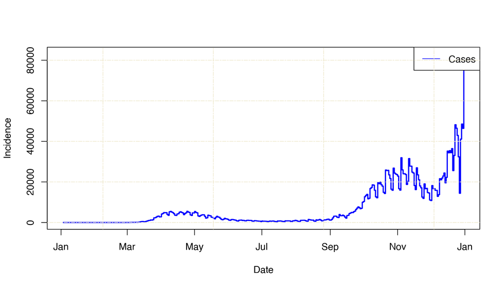

**Figure 1:** Incidence of cases over time for the ongoing COVID-19 outbreak in the U.K.

```r
plot_case_data(df_covid_uk_subset)
```

Then, we plot the death incidence data with following command:

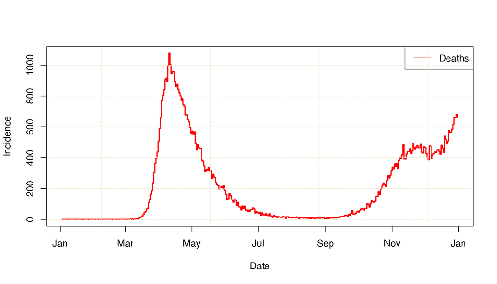

**Figure 2:** Incidence of deaths over time for the ongoing COVID-19 outbreak in the U.K.

```r
plot_death_data(df_covid_uk_subset)
```

## The delay distribution

We again retrieve the appropriate distribution (reported [here](https://doi.org/10.3390/jcm9020538)<sup>[2]</sup>), using the `epidist_db()` function from the `epiparameter` package, using the following command:

```r
onset_to_death_covid <- epidist_db(
  disease = "COVID-19",
  epi_dist = "onset_to_death",
  author = "Linton_etal"
)
```

To visualise this distribution, we evaluate it between 0 and 30 days, and plot the results over time. We do so using the following command:

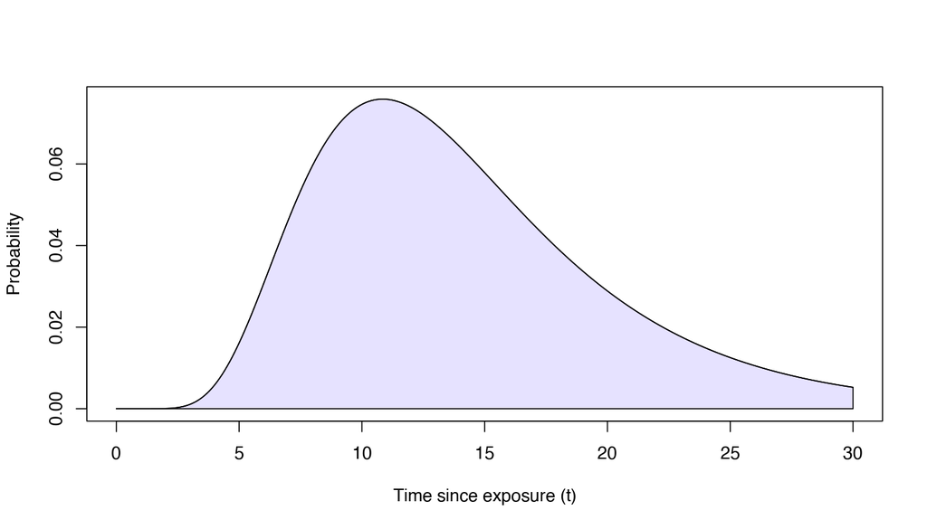

**Figure 3: Example plot of the appropriate delay distribution for the COVID-19 epidemic in the U.K.** We plot the onset-to-death distribution we use throughout this example for COVID-19, reported in https://doi.org/10.3390/jcm9020538.

```r
plot_epiparameter_distribution(onset_to_death_covid, by = 0.1)
```

## Estimating the naive and corrected CFR

We use the `estimate_time_varying()` function within the `datadelay` package to calculate the time-varying CFR for the COVID-19 epidemic in the U.K:

```r
# calculating the naive time-varying CFR
df_covid_cfr_uk_naive <- estimate_time_varying(
  df_covid_uk_subset,
  epi_dist = onset_to_death_covid,
  smooth_inputs = TRUE,
  burn_in = TRUE,
  correct_for_delays = FALSE)

df_covid_cfr_uk_corrected <- estimate_time_varying(
  df_covid_uk_subset,
  epi_dist = onset_to_death_covid,
  smooth_inputs = TRUE,
  burn_in = TRUE,
  correct_for_delays = TRUE)
```

Once we have calculated both severity quantities over time, we plot the results. First we plot the naive — uncorrected for delays — estiamte:

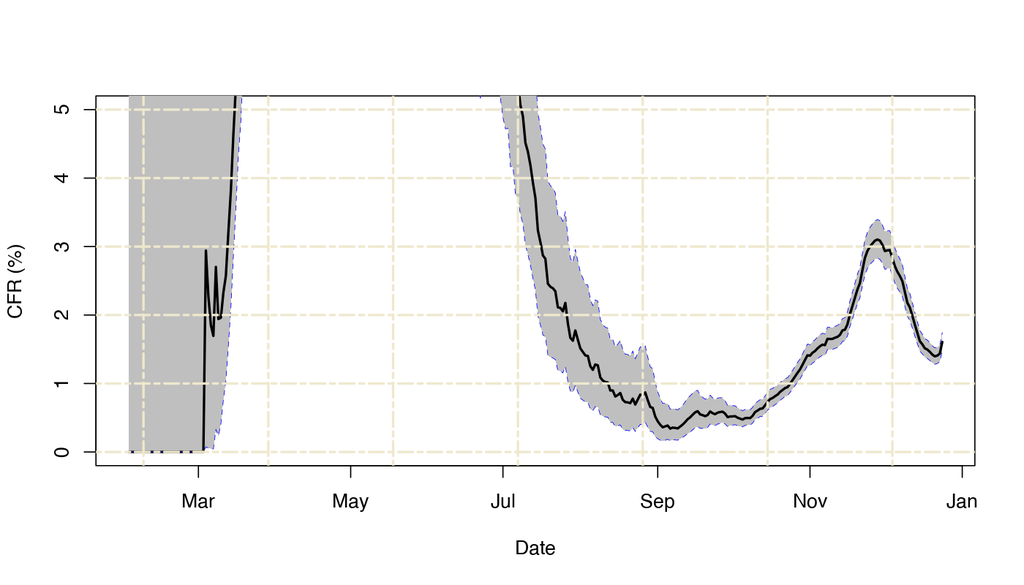

**Figure 3: Example plot of the naive time-varying CFR.** We calculate the time-varying CFR for the ongoing COVID-19 epidemic in the U.K., uncorrected for delays.

```r
plot_time_varying(df_covid_cfr_uk_naive, lower = 0, upper = 5)
```

Lastly, we plot the corrected — for delays — estimate:

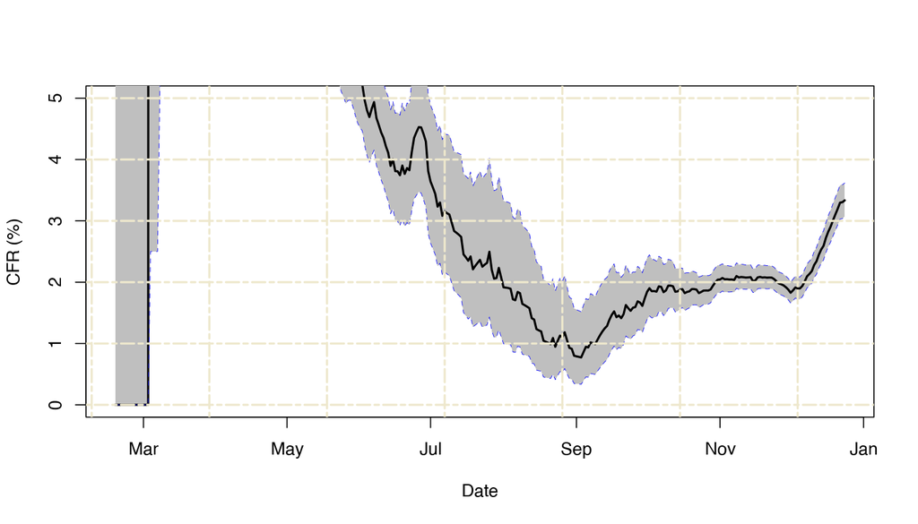

**Figure 4: Example plot of the corrected time-varying CFR.** We calculate the time-varying CFR for the ongoing COVID-19 epidemic in the U.K., corrected for delays.

```r
plot_time_varying(df_covid_cfr_uk_corrected, lower = 0, upper = 5)
```

# Example using COVID-19 data from multiple countries

This section uses functions from the `dplyr` package. It does so for two reasons: `covidregionaldata`, the package we use to download the raw data, downloads it as a `tibble`, the in-built data.frame class of the `dplyr` package and because the package includes functions which allow the user to easily map a function across one `tibble`, separated by groups. In our case, we wish the run the `estimate_time_varying()` function across all countries. The `tibble` contains data from all countries. We could make a separate `tibble` for each country we wish to run. However, as the package `dplyr` already contains the functionality to run a function across a large `tibble`, separated by a group, we use it. Furthermore, `dplyr`, as part of the `tidyverse` is a common package, which many users will already have installed.

First of all, we retrieve daily case and death data for COVID-19 for all countries, again using the `covidregionaldata` package:

```r
 df_covid <- get_national_data(
   source = "who",verbose = FALSE) |>
   rename(cases = cases_new, deaths = deaths_new)
```

Next, we run some `dplyr` commands to group the data and map the `estimate_time_varying()` function across each group within the `tibble`. We do not focus on the `dplyr` commands in this vignette. Instead, we refer the user to the `dplyr` documentation [here](https://dplyr.tidyverse.org/).

```r
df_covid_cfr <- df_covid |>
  group_by(iso_code) |>
  mutate(total_deaths = max(deaths_total)) |>
  filter(total_deaths > 100000 & !is.na(country)) |>
  group_map(~estimate_time_varying(
    df_in = .,
    epi_dist = onset_to_death_covid,
    smooth_inputs = TRUE,
    smoothing_window = 7,
    burn_in = TRUE)) |>
  bind_rows()
```

Note, for simplicity, we use the same delay distribution between onset and death for all locations.

We then plot the time-varying CFR for a selection of three more countries with large outbreaks of COVID-19. First of all, we plot the time-varying CFR estimate for the COVID-19 outbreak in Brazil:

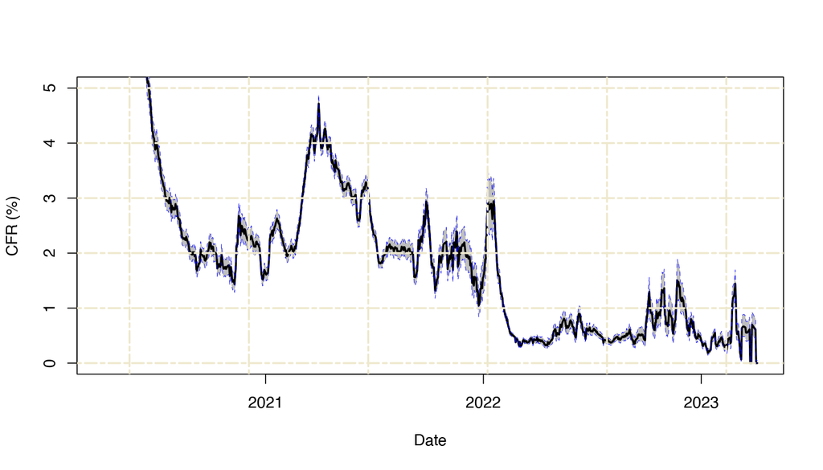

**Figure 5: Example plot of the corrected time-varying CFR.** We calculate the time-varying CFR for the ongoing COVID-19 epidemic in Brazil, corrected for delays.

```r
 subset(df_covid_cfr, country == "Brazil") |>
  plot_time_varying(lower = 0, upper = 5)
```

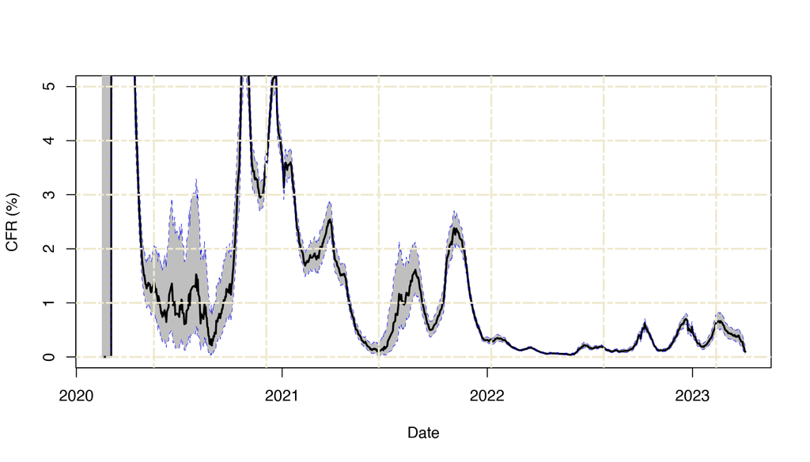

**Figure 6: Example plot of the corrected time-varying CFR.** We calculate the time-varying CFR for the ongoing COVID-19 epidemic in Germany deaths in total, corrected for delays.

```r
 subset(df_covid_cfr, country == "Germany") |>
   plot_time_varying(lower = 0, upper = 5)
```

Next, we plot the time-varying CFR estimate for the COVID-19 outbreak in the United States:

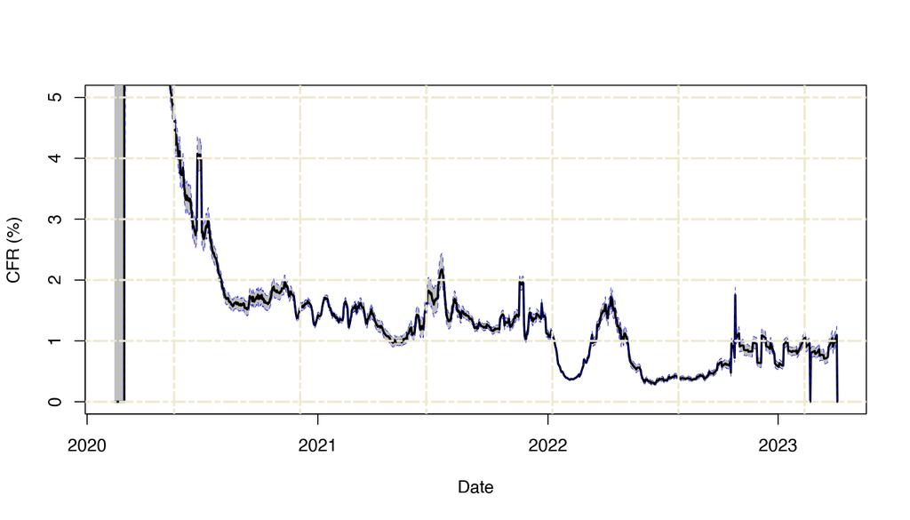

**Figure 7: Example plot of the corrected time-varying CFR.** We calculate the time-varying CFR for the ongoing COVID-19 epidemic in United States, corrected for delays.

```r
 subset(df_covid_cfr, country == "United States") |>
   plot_time_varying(lower = 0, upper = 5)
```

Finally, we plot all of the countries we have calculated the time-varying CFR for, using the package `ggplot2`, which contains the `facet_wrap()` function. This allows us to loop over the different countries with ease. We do so with the following commands:

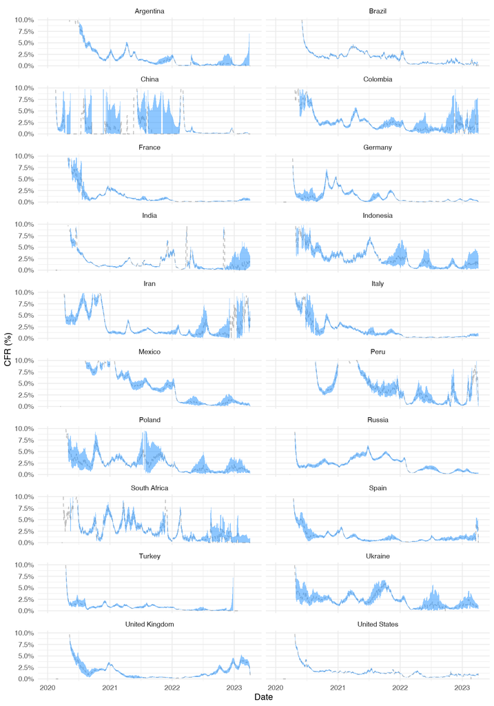

**Figure 8: The corrected time-varying CFR for each country with a large outbreak.** We calculate the time-varying CFR for the ongoing COVID-19 epidemic in each country with a large outbreak — defined as any country with more than 100,000 deaths in total — corrected for delays.

```r
 df_covid_cfr |>
  ggplot(aes(x = date)) +
  geom_line(aes(y = severity_me), linetype = "dashed", alpha = 0.25) +
  geom_ribbon(aes(ymin = severity_lo,
                  ymax = severity_hi),
              fill = "dodgerblue", alpha = 0.5) +
  coord_cartesian(clip = "off") +
  facet_wrap(~country, ncol = 2) +
  theme_minimal() +
  labs(x = "Date", y = "CFR (%)") +
  scale_y_continuous(labels = percent, limits = c(0, 0.1))
```

We do not focus on the `ggplot2` commands in this vignette. Instead, we refer the user to the `ggplot2` documentation [here](https://ggplot2.tidyverse.org/0).

1

Nishiura H, Klinkenberg D, Roberts M, *et al.* Early epidemiological assessment of the virulence of emerging infectious diseases: A case study of an influenza pandemic. *PloS one* 2009;**4**:e6852.

2

Linton NM, Kobayashi T, Yang Y, *et al.* Incubation period and other epidemiological characteristics of 2019 novel coronavirus infections with right truncation: A statistical analysis of publicly available case data. *Journal of clinical medicine* 2020;**9**:538.